# Memòria anual Salut Mental Perinatal Hospital del Mar

Any 2025

Dani Bergé

2026-01-21

El programa de salut mental perinatal de l’Hospital del Mar es coordina de forma estreta amb els serveis de l’ASSIR de la zona de referència (Sant Martí i Ciutat Vella), tant a nivell dels professionals de ginecologia-obstetricia, llevadors/es i pscicologia, així com amb treball social del servei d’hospitalització d’obstetricia-ginecologia i pediatria. Pot rebre derivacions via correu electrònic ( psiperinatal@hmar.cat ), derivació ordinària entre serveis o derivació ordinària i via IS3 des d’atenció primària.

# Visites ambulatòries

En total s’han programat **156 primeres visites (noves pacients)** aquest any 2025, el que suposa un 11% d’increment relatiu en relació a l’any anterior

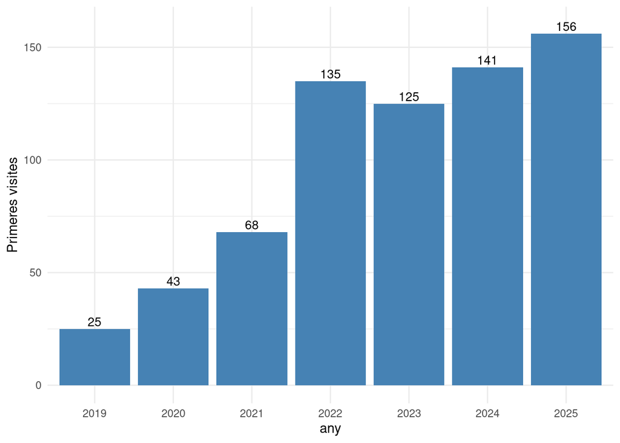

D’aquestes primeres visites, no s’han presentat en primera instància 32 pacients, el que representa un 20.51%, i no s’han presentat en cap intent de citar-les en primera visita durant aquest any 20 pacients, el que suposa un 12.82% del total de primeres visites programades.

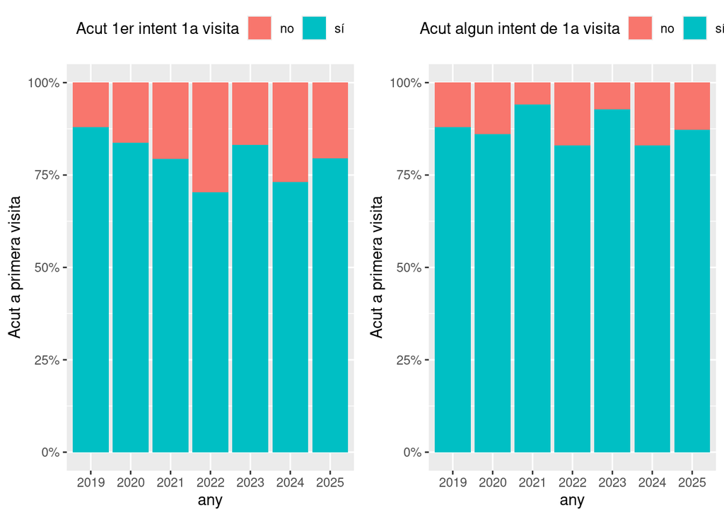

## Visites successives:

S’han programat **1558 visites successives** , i efectuat un total de **1170 visites successives**, de les quals 210 han estat per videotrucada. El ratio ha estat de 8.603 visites successives per cada primera visita.

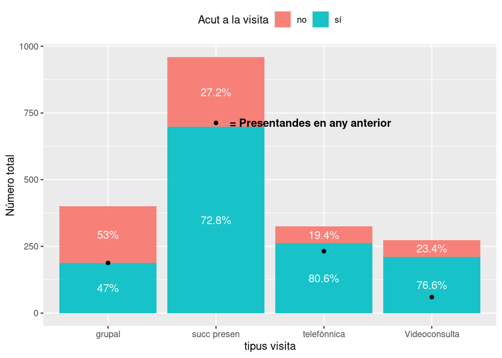

S’han efectuat també **4 edicions de grups terapèutics** amb vocació psico-educativa durant el postaprt, atenent a 53 pacients en aquesta modalitat, el que suposa un total de 188 visites grupals efectuades.

# Temps d’espera a 1a visita

Durant l’any 2025, el temps d’espera mitjà desde la derivació a la primera visita programada ha estat de **21.73** dies, amb una desviació de 19.39. En el següent gràfic es pot veure la distribució de l’any actual i dels anteriors.

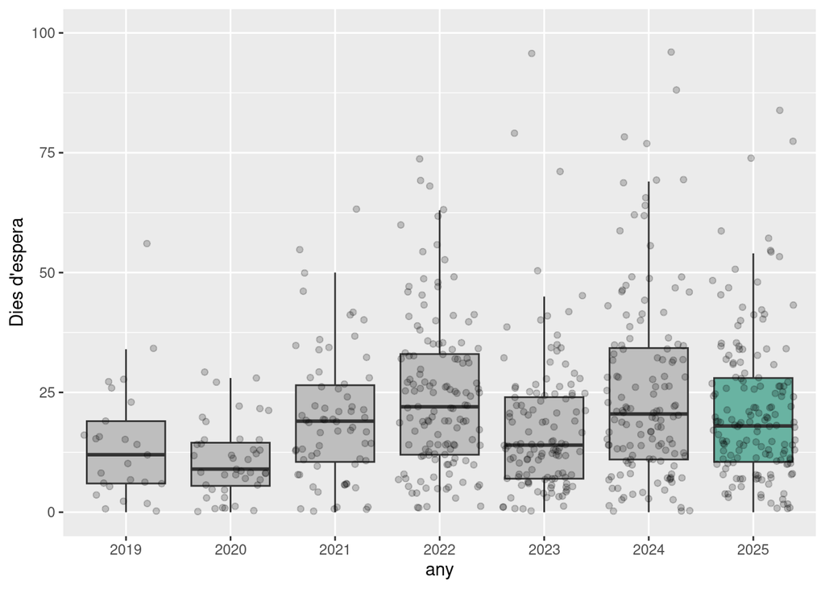

# Procedència de les derivacions

Durant l’any 2025 les principals fonts de derivació ha estat l’ASSIR tal i com es pot veure a la següent gràfica:

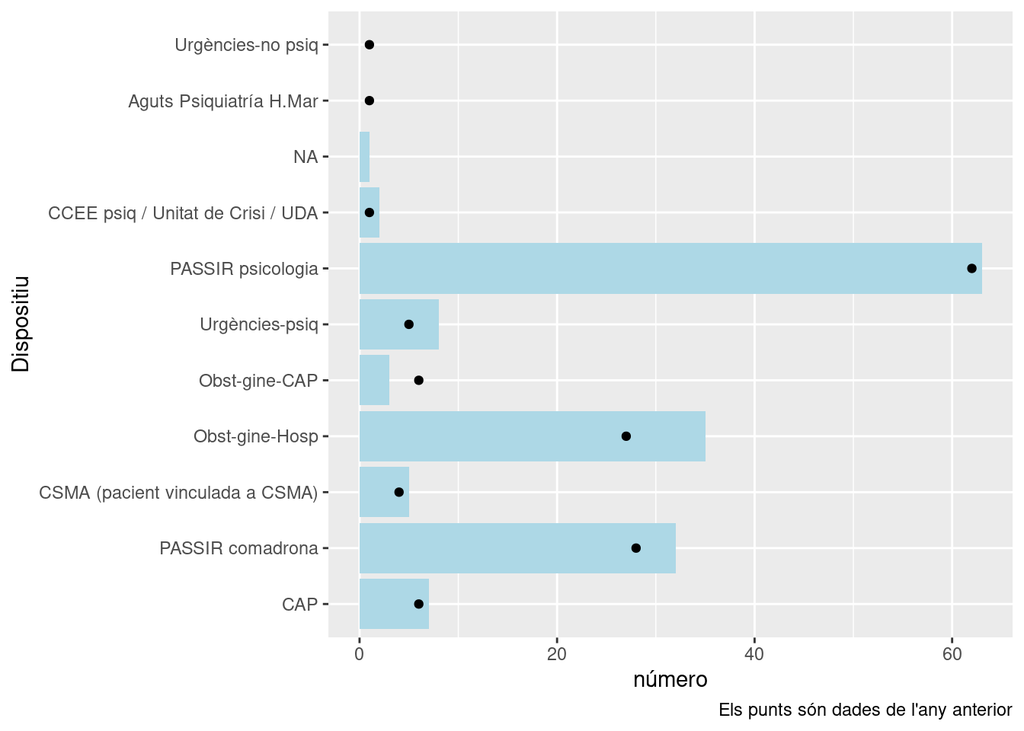

# Motiu de les derivacions

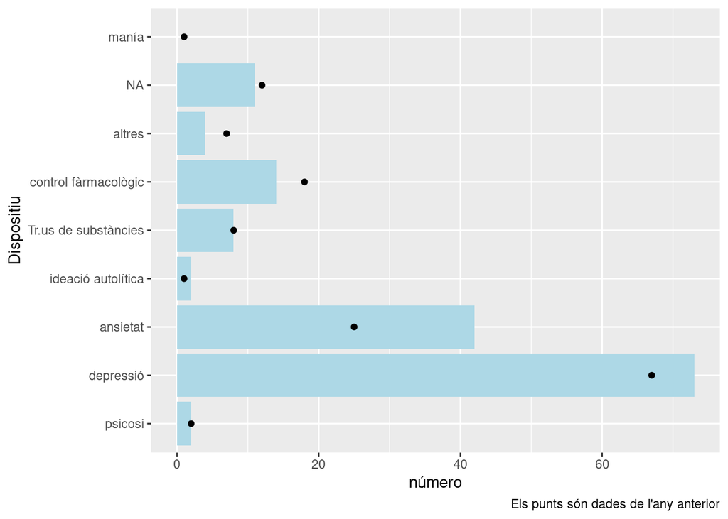

# Característiques de les pacients:

## Estat obstètric inicial

La majoria de derivacions s’efectuen durant el postpart, seguit de la gestació, amb una tendència a l’alça en el postpart en aquest darrar any.

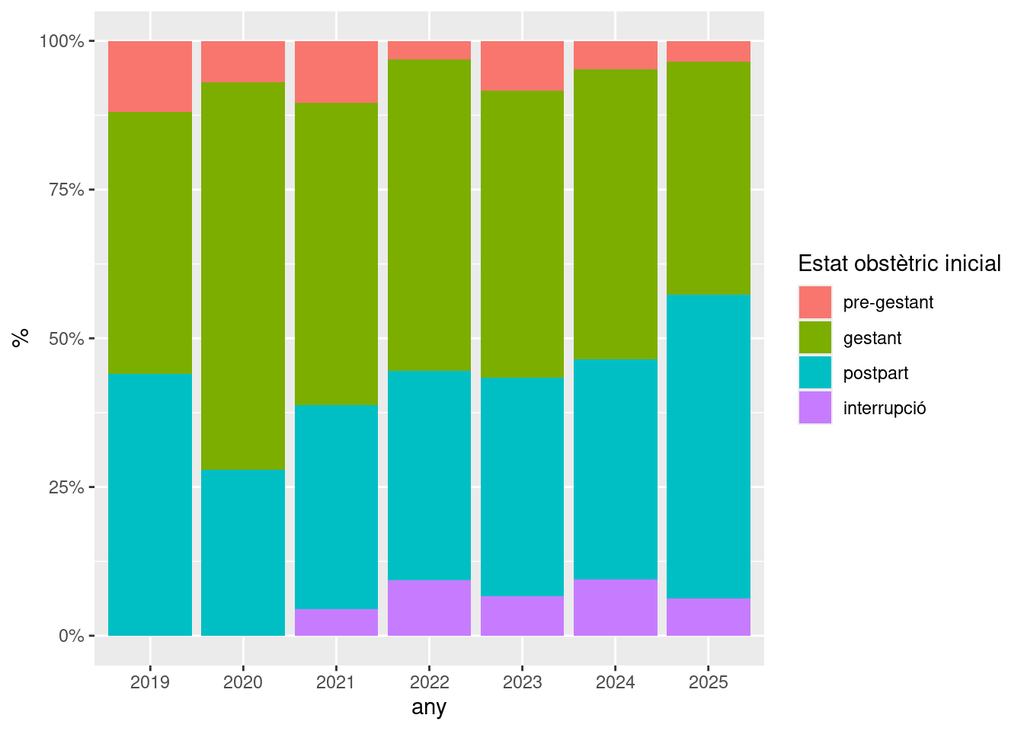

## Setmanes de gestació a la derivació

De les pacients que van ser derivades durant la gestació, la mitja de l’edat gestacional en el moment de la derivació era de 20.71 setmanes, amb una desviació de 8.82.

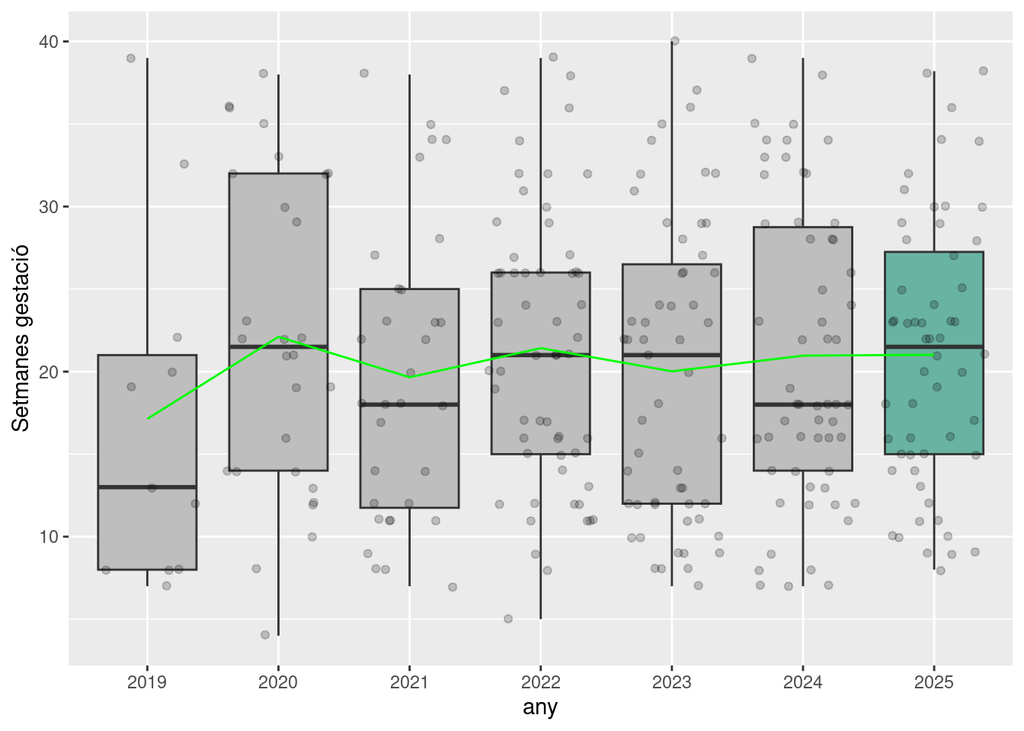

## Setmanes postpart a la derivació

De les pacients que van ser derivades durant el postpart, el promig de temps des del part va ser de 17.35 setmanes, amb una desviació de 13.35

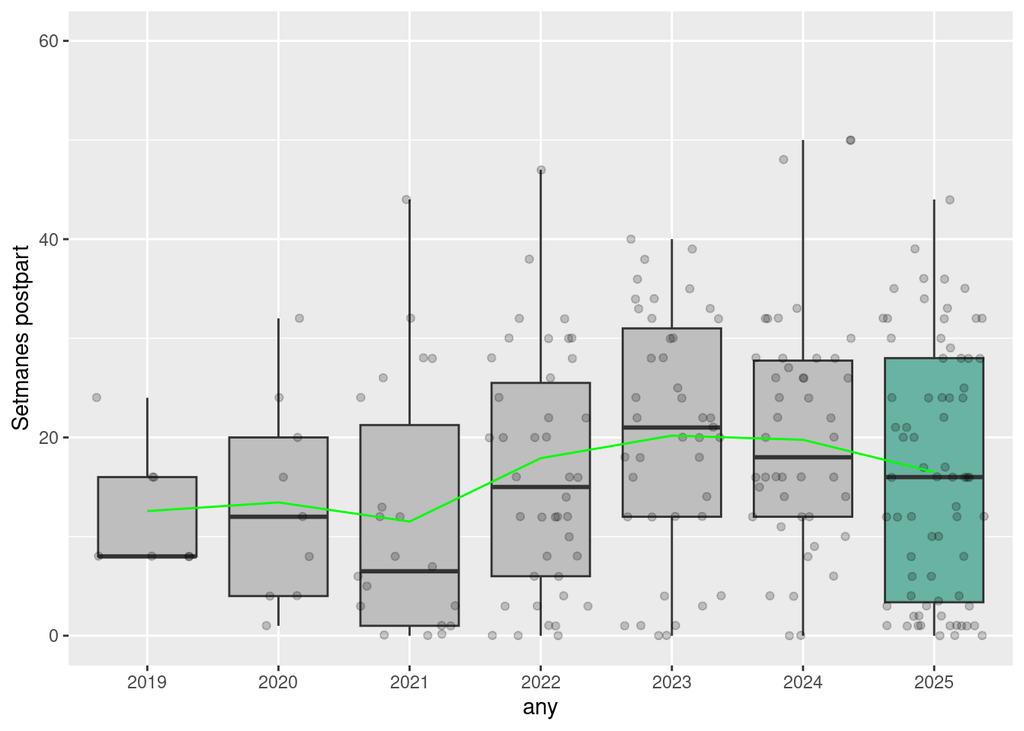

## Edat

L’edat de les pacients quan són derivades en promig és de 33.02 anys, amb una desviació de 6.3

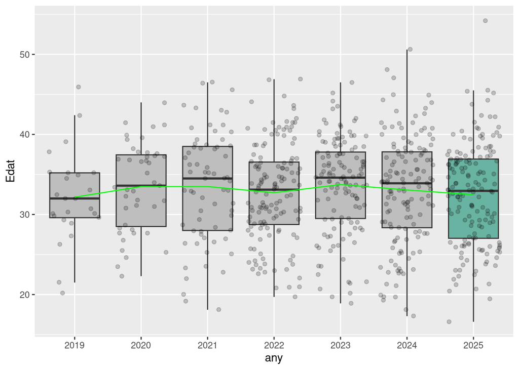

## Ètnia

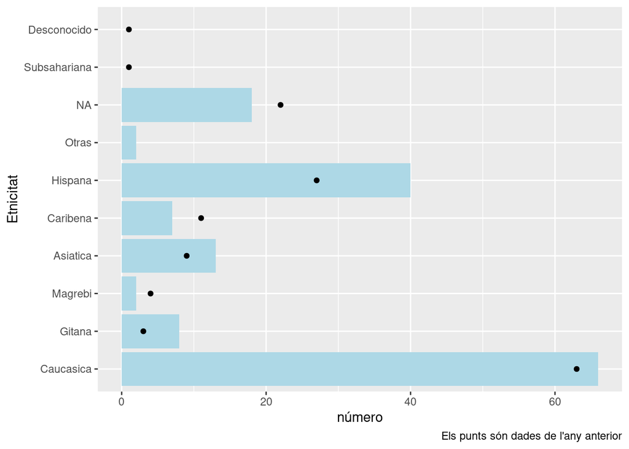

# Objectius any anterior: 2025

### 1. Disminuïr % No presentats en primeres visites

**Any 2025**:  
Durant l’any 2025 s’han elaborat fulletons on s’explica el programa de psiquiatría perinatal, que es difonen als ASSIRs quan es s’ofereix visita amb el servei. [Aquí](https://psmar-my.sharepoint.com/:b:/g/personal/dberge_hmar_cat/IQD_NnYaA-LsQ7mzdQX4W8AjAar8i0kqW4ZRxUjV9lPQdks?e=MCd7ad) es pot obtenir una còpia del fulletó. També s’ha reforçat el recordatori de la primera visita en els dies precedents per part del servei administratiu. S’han continuat les mesures prèvies que eren: 1) contacte directe telefònic entre professionals de l’ASSIR i el personal administatiu de programar les visites a salut mental perinatal de l’hospital i 2) obtenció de el dia i hora de la visita al moment en contactar per telèfon.

- No s’han presentat en primera instància 32 pacients, el que representa un 20.51%.
- No s’han presentat en cap intent de citar-les en primera visita durant aquest any 20 pacients, el que suposa un 12.82% del total de primeres visites programades.
- En comparació amb l’any **2024** , on van faltar en primera instància 26.95%, i després de diversos intents un total de 24 pacients, el que suposa un 17.02%
- **Això suposa una reducció en percentatges absoluts del 4.2 %, i una reducció en percentatges relatius del 24.68%**

### 2. Inici visites domiciliàries

S’ha consensuat el circuit de visites domiciliares del servei de psiquiatria periantal en coordinació amb les visites de llevadores dels ASSIR. S’han efectuat un total de 7 visites domiciliàries domiciliàries en el postpart, corresponent a 4 pacients. La primera visita domiciliària postpart s’efectúa en un promig de 10.25 dies des del part. Totes les pacients que han rebut aquest servei tenien un diagnòstic de trastorn psicòtic.

A part del psiquiatra, la 1a visita es va fer amb:

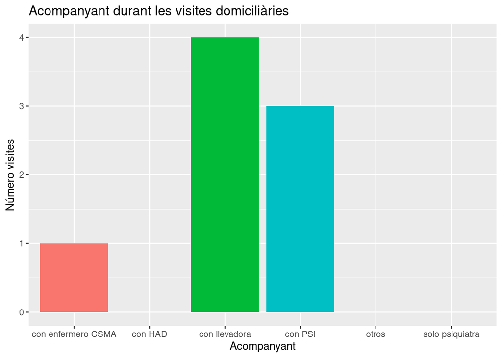

### 3. Estructurar coordinació amb EAIAs

Degut als canvis soferts a la DGAIA, actualment DGPPIA, no ha estat possible establir un circuit estable de reunions amb els serveis i dispositius afins.